# hw2

Mitul Marimuthu

2026-05-10

```r
data <- read.csv("./datasets/Dataset.csv")
```

```r
class(data['Energy_Consumption_kWh'])
head(data['Energy_Consumption_kWh'])
```

[output not shown]

```r
null_model <- lm(Energy_Consumption_kWh ~ 1, data = data)
```

```r
null_model$coefficients
```

```
## (Intercept)
##    102.8555
```

```r
mean(data$Energy_Consumption_kWh)
```

```
## [1] 102.8555
```

```r
sse_null <- sum(resid(null_model)^2)
sse_null
```

```
## [1] 16436.42
```

```r
summary(null_model)
```

```
##
## Call:
## lm(formula = Energy_Consumption_kWh ~ 1, data = data)
##
## Residuals:
##     Min      1Q  Median      3Q     Max
## -28.178 -14.780   0.021  11.335  39.273
##
## Coefficients:
##             Estimate Std. Error t value Pr(>|t|)
## (Intercept)   102.86       2.59   39.71   <2e-16 ***
## ---
## Signif. codes:  0 '***' 0.001 '**' 0.01 '*' 0.05 '.' 0.1 ' ' 1
##
## Residual standard error: 18.31 on 49 degrees of freedom
```

```r
sim_lin_reg = lm(data$Energy_Consumption_kWh ~ data$Temperature_C, data = data)
```

```r
summary(sim_lin_reg)
```

```
##
## Call:
## lm(formula = data$Energy_Consumption_kWh ~ data$Temperature_C,
##     data = data)
##
## Residuals:
##      Min       1Q   Median       3Q      Max
## -12.5034  -2.4541   0.0241   3.4235   8.3998
##
## Coefficients:
##                    Estimate Std. Error t value Pr(>|t|)
## (Intercept)        50.93031    2.04439   24.91   <2e-16 ***
## data$Temperature_C  2.45531    0.09158   26.81   <2e-16 ***
## ---
## Signif. codes:  0 '***' 0.001 '**' 0.01 '*' 0.05 '.' 0.1 ' ' 1
##
## Residual standard error: 4.63 on 48 degrees of freedom
## Multiple R-squared:  0.9374, Adjusted R-squared:  0.9361
## F-statistic: 718.8 on 1 and 48 DF,  p-value: < 2.2e-16
```

```r
sse_lin <- sum(resid(sim_lin_reg)^2)
```

```r
sse_null
```

```
## [1] 16436.42
```

```r
sse_lin
```

```
## [1] 1028.839
```

The simple linear regression model has a smaller SSE, therefore it is a better model.

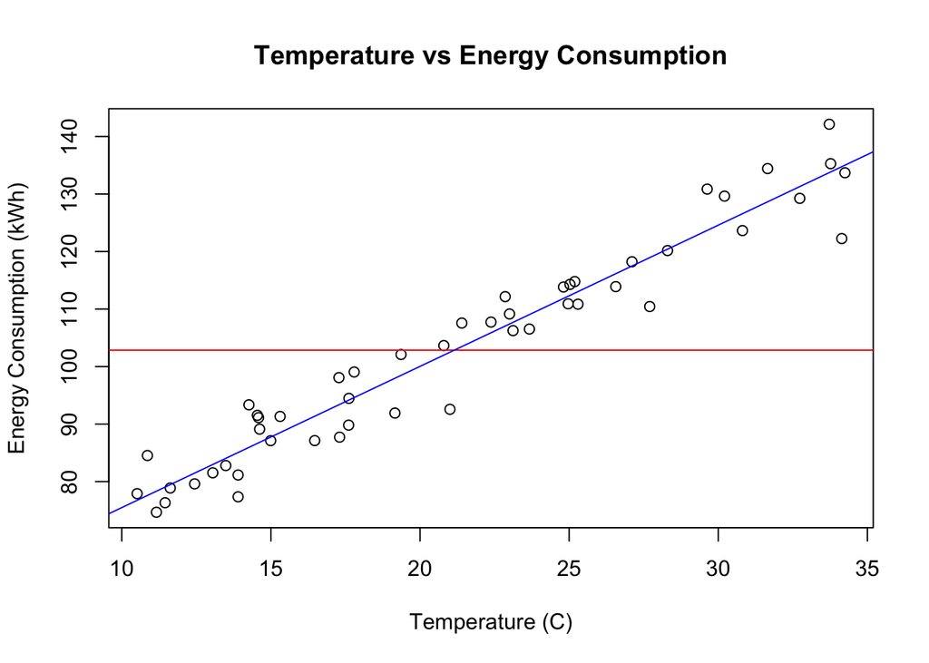

```r
plot(data$Temperature_C, data$Energy_Consumption_kWh, xlab = "Temperature (C)",
     ylab = "Energy Consumption (kWh)", main = "Temperature vs Energy Consumption")
abline(null_model, col = "red")
abline(sim_lin_reg, col = "blue")
```

```r
summary(null_model)
```

```
##
## Call:
## lm(formula = Energy_Consumption_kWh ~ 1, data = data)
##
## Residuals:
##     Min      1Q  Median      3Q     Max
## -28.178 -14.780   0.021  11.335  39.273
##
## Coefficients:
##             Estimate Std. Error t value Pr(>|t|)
## (Intercept)   102.86       2.59   39.71   <2e-16 ***
## ---
## Signif. codes:  0 '***' 0.001 '**' 0.01 '*' 0.05 '.' 0.1 ' ' 1
##
## Residual standard error: 18.31 on 49 degrees of freedom
```

## 1a. Null Model summary description

The residuals section shows the distribution of the residuals with min at -28.178 and max at 39.273.

Coefficents section:

- The value for $\hat{\beta}_0$ is 102.86, which is the mean of the data in the null model
- The standard error is 2.59, indicating that estimates for $\hat{\beta}_0$ deviate from the population parameter by 2.59 on average.
- The t-value is 39.71 meaning the value for $\hat{\beta}_0$ is 39.71 standard errors away from 0, and it’s corresponding p-value (with a null hypothesis of $\beta_0 = 0$) is very small. This indicates that there is statistically significant evidence that $\beta_0 \neq 0$.
- A residual standard error of 18.31 indicates that the actual values deviate from their predicted values by 18.31 on average.

```r
summary(sim_lin_reg)
```

```
##
## Call:
## lm(formula = data$Energy_Consumption_kWh ~ data$Temperature_C,
##     data = data)
##
## Residuals:
##      Min       1Q   Median       3Q      Max
## -12.5034  -2.4541   0.0241   3.4235   8.3998
##
## Coefficients:
##                    Estimate Std. Error t value Pr(>|t|)
## (Intercept)        50.93031    2.04439   24.91   <2e-16 ***
## data$Temperature_C  2.45531    0.09158   26.81   <2e-16 ***
## ---
## Signif. codes:  0 '***' 0.001 '**' 0.01 '*' 0.05 '.' 0.1 ' ' 1
##
## Residual standard error: 4.63 on 48 degrees of freedom
## Multiple R-squared:  0.9374, Adjusted R-squared:  0.9361
## F-statistic: 718.8 on 1 and 48 DF,  p-value: < 2.2e-16
```

## 1b. Simple Linear Regression Model summary description

The residuals section shows the distribution of the residuals, with a min of -12.5034 and a max od 8.3998

Coefficients section:

- Intercept: $\hat{\beta}_0$ = 50.93031. It’s standard error is 2.04439 meaning estimates for the intercept deviate from the true population parameter by 2.04439. It’s t-value ie 24.91 meaning $\hat{\beta}_0$ is 24.91 stanard errors away from 0 which produces a p-value that is very small, indicating that there is strong statistical evidence that $\hat{\beta}_0 \neq 0$.
- `data$Temperature_C`: $\hat{\beta}_1$ = 2.45531. It’s standard error is 0.09158 meaning estimates for the slope deviate from the true population parameter by 0.09158 on average. It’s t-value is 26.81 meaning $\hat{\beta}_1$ is 26.81 standard errors away from 0 which produces a p-value that is very small, indicating that there is strong statistical evidence that $\hat{\beta}_1 \neq 0$.
- The residual standard error is 4.63, indicating the average deviation of 4.63 of actual values from their predicted values
- $R^2$ = 0.9374 indicating that around 93.74% of the variance in energy consumption is explained by temperature
- A large F-statistic and low p-value indicate that this model is better than just using the mean.

## 2. 95% confidence intervals and prediction intervals.

### Null-model confidence interval for all estimates

```r
ci = predict(null_model, interval="confidence", level = 0.95)
ci
```

```
##         fit      lwr      upr
## 1  102.8555 97.65047 108.0606
## 2  102.8555 97.65047 108.0606
## 3  102.8555 97.65047 108.0606
## 4  102.8555 97.65047 108.0606
## 5  102.8555 97.65047 108.0606
## 6  102.8555 97.65047 108.0606
## 7  102.8555 97.65047 108.0606
## 8  102.8555 97.65047 108.0606
## 9  102.8555 97.65047 108.0606
## 10 102.8555 97.65047 108.0606
## 11 102.8555 97.65047 108.0606
## 12 102.8555 97.65047 108.0606
## 13 102.8555 97.65047 108.0606
## 14 102.8555 97.65047 108.0606
```

[output cut: 36 more lines]

### Null-model prediction interval

```r
pi = predict(null_model, interval="prediction", level = 0.95)
pi
```

```
##         fit      lwr     upr
## 1  102.8555 65.68403 140.027
## 2  102.8555 65.68403 140.027
## 3  102.8555 65.68403 140.027
## 4  102.8555 65.68403 140.027
## 5  102.8555 65.68403 140.027
## 6  102.8555 65.68403 140.027
## 7  102.8555 65.68403 140.027
## 8  102.8555 65.68403 140.027
## 9  102.8555 65.68403 140.027
## 10 102.8555 65.68403 140.027
## 11 102.8555 65.68403 140.027
## 12 102.8555 65.68403 140.027
## 13 102.8555 65.68403 140.027
## 14 102.8555 65.68403 140.027
```

[output cut: 36 more lines]

### Simple linear regression model confidence interval

```r
ci_slr = predict(sim_lin_reg, interval="confidence", level=0.95)
ci_slr
```

```
##          fit       lwr       upr
## 1   98.47378  97.11695  99.83061
## 2  133.84098 131.17030 136.51166
## 3  120.41531 118.55328 122.27733
## 4  112.23080 110.73837 113.72322
## 5   85.06031  83.18576  86.93486
## 6   85.05883  83.18420  86.93346
## 7   79.04878  76.83058  81.26699
## 8  128.65179 126.31183 130.99175
## 9  112.38159 110.88380 113.87937
## 10 118.94695 117.16110 120.73279
## 11  76.74698  74.38762  79.10634
## 12 135.01926 132.27135 137.76716
## 13 126.58113 124.36782 128.79444
## 14  88.51742  86.81766  90.21718
```

[output cut: 36 more lines]

### Simple linear regression model prediction interval

```r
pi_slr = predict(sim_lin_reg, interval="prediction", level=0.95)
pi_slr
```

```
##          fit       lwr       upr
## 1   98.47378  89.06677 107.88079
## 2  133.84098 124.15680 143.52516
## 3  120.41531 110.92226 129.90835
## 4  112.23080 102.80328 121.65832
## 5   85.06031  75.56480  94.55582
## 6   85.05883  75.56331  94.55436
## 7   79.04878  69.47950  88.61807
## 8  128.65179 119.05355 138.25003
## 9  112.38159 102.95322 121.80996
## 10 118.94695 109.46855 128.42534
## 11  76.74698  67.14399  86.34997
## 12 135.01926 125.31350 144.72502
## 13 126.58113 117.01298 136.14928
## 14  88.51742  79.05487  97.97998
```

[output cut: 36 more lines]

# 3. Which model

The simple linear regression model has a smaller RSE, higher $R^2$ value and higher F-value so therefore I would rather have the simple linear regression model over the null model.

# 4. Interpretations

## 4a. Null Model

- The intercept is 102.86, meaning that the energy consumed is 102.86 kWh on average.
- The standard error is 2.59, indicating that estimates for the intercept deviate from the population parameter by 2.59 on average.
- The t-value is 39.71 meaning the value for $\hat{\beta}_0$ is 39.71 standard errors away from 0, and it’s corresponding p-value (with a null hypothesis of $\beta_0 = 0$) is very small. This indicates that there is statistically significant evidence that $\beta_0 \neq 0$.

## 4b. Simple Linear Regression Model

- Intercept: $\hat{\beta}_0$ = 50.93031. This means that when the temperature is 0 degrees Celsius, the energy consumed in 50.93031 kWh. It’s standard error is 2.04439 meaning estimates for the intercept deviate from the true population parameter by 2.04439. It’s t-value ie 24.91 meaning $\hat{\beta}_0$ is 24.91 stanard errors away from 0 which produces a p-value that is very small, indicating that there is strong statistical evidence that $\hat{\beta}_0 \neq 0$.
- `data$Temperature_C`: $\hat{\beta}_1$ = 2.45531. This means that for each 1 degree Celsius increase in temperature, the energy consumed increases by 2.45531 kWh. It’s standard error is 0.09158 meaning estimates for the slope deviate from the true population parameter by 0.09158 on average. It’s t-value is 26.81 meaning $\hat{\beta}_1$ is 26.81 standard errors away from 0 which produces a p-value that is very small, indicating that there is strong statistical evidence that $\hat{\beta}_1 \neq 0$.
- The residual standard error is 4.63, indicating the average deviation of 4.63 of actual values from their predicted values
- $R^2$ = 0.9374 indicating that around 93.74% of the variance in energy consumption is explained by temperature
- A large F-statistic and low p-value indicate that this model is better than just using the mean.